# PPDFinal

Charlie Huemmler and Simps Bhebhe

2022-11-29

# SF Park App

### Video Link

[Video Link](https://www.youtube.com/watch?v=lx4p8_5dQRk&ab_channel=SimphiweJonah)

## Introduction and Motivation

The use case for this analysis is to provide potential drivers with an indication of where parking is available in advance, so that they can plan accordingly and save time and money. The approach taken is to utilize San Francisco open parking data to forecast parking demand at a block level, which will give potential drivers a better understanding of where they are most likely to find a parking spot. This analysis is useful for any city with limited parking resources. By replicating the analysis, cities can gain insight into the occupancy of each parking block and predict the demand for parking in the future. This can help city planners allocate resources more efficiently and create better parking policies. It can also help drivers, visitors and residents of the city in finding parking spots more quickly and reduce their carbon footprint.

```r
knitr::opts_chunk$set(
  warning=FALSE,
  message=FALSE,
  results='hide')
```

```r
library(tidyverse)
library(sf)
library(lubridate)
library(tigris)
library(RSocrata)
library(purrr)
library(riem)
library(gganimate)
library(ggridges)
library(viridis)
library(scales)
library(cowplot)
library(caret)
library(knitr)
library(pscl)
library(plotROC)
library(pROC)
library(hms)


sf::sf_use_s2(FALSE)

options(tigris_class = "sf")
source("https://raw.githubusercontent.com/urbanSpatial/Public-Policy-Analytics-Landing/master/functions.r")
```

```r
meters <- read.socrata('https://data.sfgov.org/resource/8vzz-qzz9.json') %>% st_as_sf(coords = c('longitude','latitude'),crs = 4326)
```

```r
trips1 <- read.socrata("https://data.sfgov.org/resource/imvp-dq3v.csv?$where=session_start_dt between '2021-06-07T00:00:00' and '2021-06-28T00:00:00'")

trips <- trips1 %>% mutate(
  start_time = session_start_dt %>% as_datetime(),
  end_time = session_end_dt %>% as_datetime(),
  length_secs = (end_time - start_time),
  rate = gross_paid_amt/as.numeric(length_secs/60),
  hour = start_time %>% hour(),
  dotw = start_time %>% wday(label = T),
  weekend = ifelse(dotw %in% c('Sun','Sat'),1,0),
  end_interval15 = floor_date(ymd_hms(session_end_dt), unit = "15 mins") %>% as_datetime(),
  start_interval15 = floor_date(ymd_hms(session_start_dt), unit = "15 mins")  %>% as_datetime(),
  length = end_interval15 - start_interval15,
  timeofday = start_interval15 %>% hour() + start_interval15 %>% minute()/60) %>%
  filter(length_secs > 600 & length_secs < 21600 )
```

```r
sfbounds <- c(ymax= 100000, ymin= 63410.51,xmin= 139343.4 , xmax=177200 )

water <- area_water('CA', 'San Francisco') %>% st_transform(crs = 7132)  %>% st_crop(y=sfbounds)  %>%
  st_transform(crs = 4326)

streets <- read_sf('streets.geojson') %>% st_transform(crs = 7132)%>% st_crop(y=sfbounds) %>%
  st_transform(crs = 4326)

meters <- meters %>% mutate(on_offstreet_type = on_offstreet_type %>% factor(levels = c("ON", "OFF")),
                            capcol = case_when(cap_color == 'Black' ~"Motorcycle",
                                               cap_color == 'Brown' ~"Tour bus",
                                               cap_color == 'Purple' ~"Boat trailer",
                                               cap_color == 'Red' ~"Six wheel",
                                               cap_color == 'Yellow' ~"Commercial",
                                               cap_color == 'Green' ~"Short term",
                                               cap_color == 'Grey'~ "General",
                                               cap_color == '-' ~ 'NA'))
```

## Data and EDA

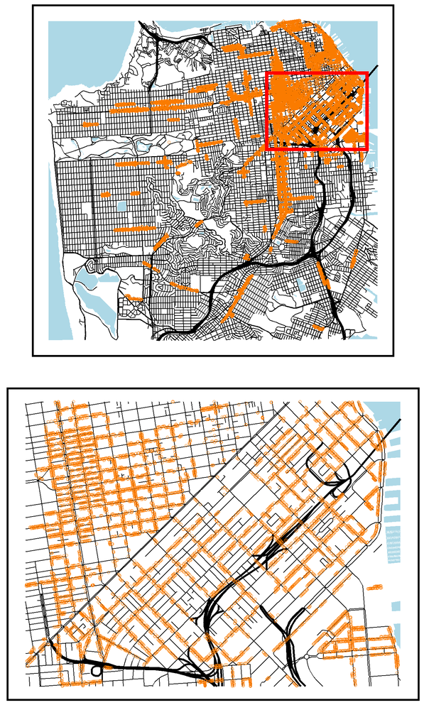

```r
#ggplotly(g)
dtbounds <- c(ymax= 37.792,ymin= 37.768,xmin= -122.426 , xmax=-122.386)
dt_meters <- meters %>% st_crop(y=dtbounds) %>% filter(meter_type %in% c('SS','-') & capcol %in% c('General','Short term', 'NA'))

trips_dt <-trips %>% filter(post_id %in% dt_meters$post_id)


k1 <- ggplot()+
  geom_sf(data = water, color = NA, fill = 'lightblue')+
  geom_sf(data = streets%>% filter(classcode ==5))+
  geom_sf(data = streets %>% filter(classcode ==1),size=1.1)+
  geom_sf(data = meters %>% filter(meter_type %in% c('SS','-') & capcol %in% c('General','Short term', 'NA')) , color = '#FA7B00', shape = 1)+
  geom_rect(aes(ymax= 37.792,ymin= 37.768,xmin= -122.426 , xmax=-122.386), fill = NA, color = 'red', size =2)+
  labs(color = '')+
  mapTheme()



 k2 <- ggplot()+
  geom_sf(data = water%>% st_crop(y=dtbounds), color = NA, fill = 'lightblue')+
  geom_sf(data = streets%>% filter(classcode ==5) %>% st_crop(y=dtbounds))+
  geom_sf(data = streets %>% filter(classcode ==1) %>% st_crop(y=dtbounds),size=1.1)+
  geom_sf(data =dt_meters, color = '#FA7B00', shape = 1)+
  mapTheme()

plot_grid(k1,k2,ncol =1 )
```

The audience of our application is limited to those looking for parking in the downtown core of San Francisco, where many destinations (work, cultural amenities, government buildings) are located. Drivers in this area cannot simply drive to an unmetered street like in other sections of the city, so they will be more susceptible to relying on our app. Our app gives parking occupancy predictions on 333 blocks.

```r
blocks <- inner_join(dt_meters, trips_dt %>%
                           select(post_id, street_block) %>% unique())

meterblock <- trips_dt %>% select(post_id, street_block) %>% unique()

metercount <- trips_dt %>% select(post_id, street_block) %>% unique() %>%
  mutate(metercounter = 1) %>% group_by(street_block) %>% summarise(metercount = sum(metercounter))




block_join <- data.frame(block = NA, geometry = blocks[1,]$geometry) %>% st_sf()

for(block in blocks$street_block %>% unique()){
  block1 <- blocks %>% filter(street_block == block)
  if(nrow(block1) >= 5){
    block2 <- st_union(block1) %>% st_sf()
    block_join <- data.frame(block = block, geometry = block2) %>% add_row(block_join, .)
}
  }


block_join <- block_join %>% slice(2:nrow(block_join))

block_join$id <- seq(1,nrow(block_join))
```

```r
# estimate parking occupancy using Sf Park data
# Code by Michael Fichman - mfichman@upenn.edu

# This is a really basic mock-up of how I estimated Pittsburgh parking occupancies to
# the 15 minute interval. I did that project before tidyverse, so it's not code that you
# would find particularly useful.

# There is 100% a better way to do this than to create a bunch of stuff in a mutate
# statement - this is prime for a looped or more algorithmic type of code. It's also very "blunt force"
# in how long it assumes people are parking - there is a lot of rounding.

# This is a panel data setup

# The basic idea is you buy, say, an hour worth of parking, and you "get" 4
# 15 minute "tokens" that can be "dropped" in the occupancy counter of each of the
# upcoming slots in the panel.

# THis is code just for a few days - but you would want to be doing this for many meters.
# This code assumes you can buy a max of 3 hours of parking (e.g. 12 tokens) - you might need to adjust that.



#dat <- read.socrata("https://data.sfgov.org/resource/imvp-dq3v.json?post_id=591-25480")

# Divide transaction lengths into 15 minute intervals
# THis is done very roughly, you might want to make this more exact
# If a transaction is, say 45 minutes, drop tokens in tokens_00, 01, 02

dat2 <- trips_dt %>% group_by(start_interval15, post_id) %>%
  mutate(tokens = as.numeric(sum(length) )/ 900,
         tokens_00 = ifelse(tokens >= 1, 1, 0),
         tokens_01 = ifelse(tokens >= 2, 1, 0),
         tokens_02 = ifelse(tokens >= 3, 1, 0),
         tokens_03 = ifelse(tokens >= 4, 1, 0),
         tokens_04 = ifelse(tokens >= 5, 1, 0),
         tokens_05 = ifelse(tokens >= 6, 1, 0),
         tokens_06 = ifelse(tokens >= 7, 1, 0),
         tokens_07 = ifelse(tokens >= 8, 1, 0),
         tokens_08 = ifelse(tokens >= 9, 1, 0),
         tokens_09 = ifelse(tokens >= 10, 1, 0),
         tokens_10 = ifelse(tokens >= 11, 1, 0),
         tokens_11 = ifelse(tokens >= 12, 1, 0),
         tokens_12 = ifelse(tokens >= 13, 1, 0),
         tokens_13 = ifelse(tokens >= 14, 1, 0),
         tokens_14 = ifelse(tokens >= 15, 1, 0),
         tokens_15 = ifelse(tokens >= 16, 1, 0),
         tokens_16 = ifelse(tokens >= 17, 1, 0),
         tokens_17 = ifelse(tokens >= 18, 1, 0),
         tokens_18 = ifelse(tokens >= 19, 1, 0),
         tokens_19 = ifelse(tokens >= 20, 1, 0),
         tokens_20 = ifelse(tokens >= 21, 1, 0),
         tokens_21 = ifelse(tokens >= 22, 1, 0),
         tokens_22 = ifelse(tokens >= 23, 1, 0),
         tokens_23 = ifelse(tokens >= 24, 1, 0),
         tokens_24 = ifelse(tokens >= 25, 1, 0))

# Summarize this data by start time and meter

dat3 <- dat2 %>%
  group_by(start_interval15, post_id) %>%
  summarize(tokens_00 = sum(tokens_00, na.rm = T),
            tokens_01 = sum(tokens_01, na.rm = T),
            tokens_02 = sum(tokens_02, na.rm = T),
            tokens_03 = sum(tokens_03, na.rm = T),
            tokens_04 = sum(tokens_04, na.rm = T),
            tokens_05 = sum(tokens_05, na.rm = T),
            tokens_06 = sum(tokens_06, na.rm = T),
            tokens_07 = sum(tokens_07, na.rm = T),
            tokens_08 = sum(tokens_08, na.rm = T),
            tokens_09 = sum(tokens_09, na.rm = T),
            tokens_10 = sum(tokens_10, na.rm = T),
            tokens_11 = sum(tokens_11, na.rm = T),
            tokens_12 = sum(tokens_12, na.rm = T),
            tokens_13 = sum(tokens_13, na.rm = T),
            tokens_14 = sum(tokens_14, na.rm = T),
            tokens_15 = sum(tokens_15, na.rm = T),
            tokens_16 = sum(tokens_16, na.rm = T),
            tokens_17 = sum(tokens_17, na.rm = T),
            tokens_18 = sum(tokens_18, na.rm = T),
            tokens_19 = sum(tokens_19, na.rm = T),
            tokens_20 = sum(tokens_20, na.rm = T),
            tokens_21 = sum(tokens_21, na.rm = T),
            tokens_22 = sum(tokens_22, na.rm = T),
            tokens_23 = sum(tokens_23, na.rm = T),
            tokens_24 = sum(tokens_24, na.rm = T))
#Create a panel consisting of all the time/meter observations in the set
# Add a day of the year to each observation, join it to the transaction data
# This might need to be tinkered with to make sure every time period for every meter is included
# There are some weird one-off transactions off hours that might need to be cleaned out

study.panel <-
  expand.grid(start_interval15=unique(dat3$start_interval15),
              post_id = unique(dat3$post_id)) %>%
  mutate(doty = yday(start_interval15)) %>%
  left_join(., dat3) %>%
  mutate_at(grep("token", names(.), value = T), ~ifelse(is.na(.), 0, .)) %>%
  arrange(start_interval15)
#%>%
  #mutate_at(c(20:45), ~replace_na(.,0))
#length(unique(dat3$start_interval15)) * length(unique(dat3$post_id))

# Estimate occupancy but compiling the current tokens and the previous tokens
# that carry forward - i think (i think) the observations at 15:00 hours are the people who start
# the day parking - not every place has the same metered hours

transaction_panel <- study.panel  %>%
  group_by(post_id, doty) %>%
  mutate(lag01 = ifelse(is.na(lag(tokens_01,1)) == FALSE, lag(tokens_01,1), 0),
         lag02 = ifelse(is.na(lag(tokens_02,2)) == FALSE, lag(tokens_02,2), 0),
         lag03 = ifelse(is.na(lag(tokens_03,3)) == FALSE, lag(tokens_03,3), 0),
         lag04 = ifelse(is.na(lag(tokens_04,4)) == FALSE, lag(tokens_04,4), 0),
         lag05 = ifelse(is.na(lag(tokens_05,5)) == FALSE, lag(tokens_05,5), 0),
         lag06 = ifelse(is.na(lag(tokens_06,6)) == FALSE, lag(tokens_06,6), 0),
         lag07 = ifelse(is.na(lag(tokens_07,7)) == FALSE, lag(tokens_07,7), 0),
         lag08 = ifelse(is.na(lag(tokens_08,8)) == FALSE, lag(tokens_08,8), 0),
         lag09 = ifelse(is.na(lag(tokens_08,9)) == FALSE, lag(tokens_09,9), 0),
         lag10 = ifelse(is.na(lag(tokens_10,10)) == FALSE, lag(tokens_10,10), 0),
         lag11 = ifelse(is.na(lag(tokens_11,11)) == FALSE, lag(tokens_11,11), 0),
         lag12 = ifelse(is.na(lag(tokens_12,12)) == FALSE, lag(tokens_12,12), 0),
         lag13 = ifelse(is.na(lag(tokens_13,13)) == FALSE, lag(tokens_13,13), 0),
         lag14 = ifelse(is.na(lag(tokens_14,14)) == FALSE, lag(tokens_14,14), 0),
         lag15 = ifelse(is.na(lag(tokens_15,15)) == FALSE, lag(tokens_15,15), 0),
         lag16 = ifelse(is.na(lag(tokens_16,16)) == FALSE, lag(tokens_16,16), 0),
         lag17 = ifelse(is.na(lag(tokens_17,17)) == FALSE, lag(tokens_17,17), 0),
         lag18 = ifelse(is.na(lag(tokens_18,18)) == FALSE, lag(tokens_18,18), 0),
         lag19 = ifelse(is.na(lag(tokens_19,19)) == FALSE, lag(tokens_19,19), 0),
         lag20 = ifelse(is.na(lag(tokens_20,20)) == FALSE, lag(tokens_20,20), 0),
         lag21 = ifelse(is.na(lag(tokens_21,21)) == FALSE, lag(tokens_21,21), 0),
         lag22 = ifelse(is.na(lag(tokens_22,22)) == FALSE, lag(tokens_22,22), 0),
         lag23 = ifelse(is.na(lag(tokens_23,23)) == FALSE, lag(tokens_23,23), 0),
         lag24 = ifelse(is.na(lag(tokens_24,24)) == FALSE, lag(tokens_24,24), 0)) %>%
  mutate(occupancy = ifelse
         (tokens_00 + lag01 + lag02 + lag03+ lag04 + lag05 +
           lag06 + lag07 + lag08 + lag09 + lag10 + lag11 + lag12 + lag13+lag14+lag15+lag16+lag17+lag18+lag19+lag20+lag21+lag22+lag23+lag24 >= 1, 1, 0)) %>% ungroup()



# join everything

transaction_panel3 <- transaction_panel %>% left_join(meterblock, by = c("post_id")) %>%
  relocate(occupancy, street_block, .after = doty) %>% filter(street_block != 0)  %>%
  mutate(start_interval15 = start_interval15 %>% as_datetime())



transaction_panel2 <- transaction_panel3 %>% select(start_interval15, post_id, occupancy, street_block) %>% left_join(metercount)




occ_panel <- transaction_panel2 %>%
  group_by(street_block, start_interval15) %>% summarise(
  parked = sum(occupancy),
  total_spots = mean(metercount),
  pct_occ = parked/total_spots) %>%
  mutate(occ_col = ifelse(pct_occ <= 1, pct_occ, 1),
             week = week(start_interval15),
             dotw = wday(start_interval15),
             day = day(start_interval15),
             hour1 = hour(start_interval15)) %>% filter(total_spots > 5 & hour1 > 8 & hour1 < 22)
```

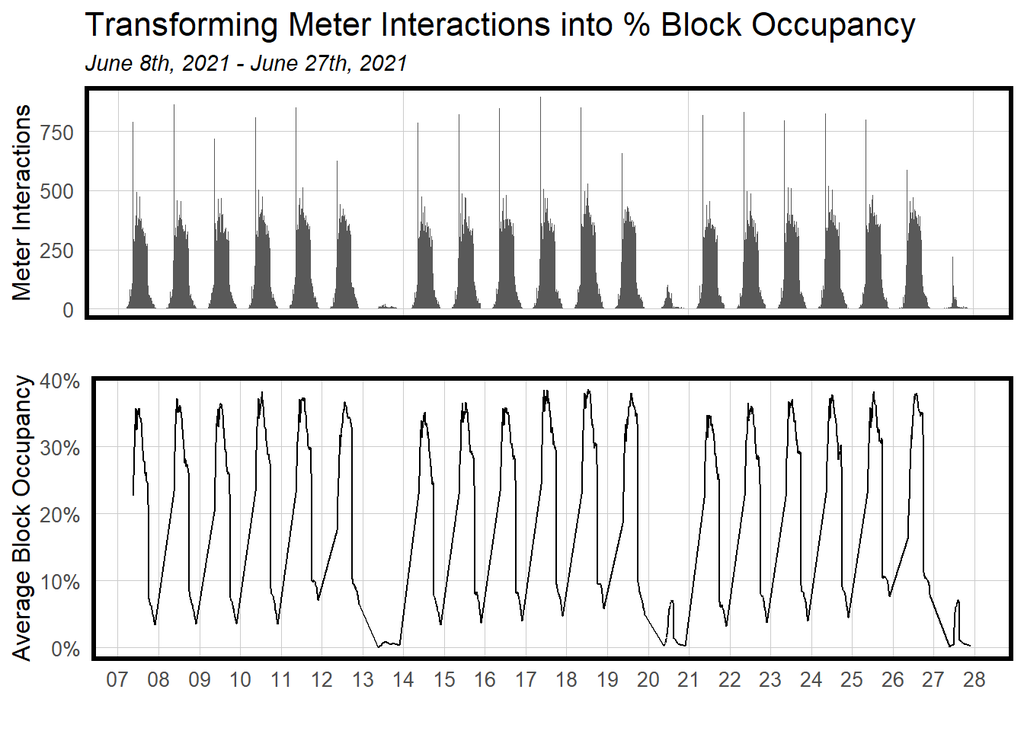

```r
t <- occ_panel %>%
  #filter(week == 25) %>%
  group_by(start_interval15) %>%
  summarize(occ = mean(occ_col),
            block = street_block, dotw = dotw)  %>%
  ungroup()
#, color = block, group = block

og1 <- ggplot(trips_dt)+
  geom_bar(aes(x = start_interval15))+
  #scale_x_datetime(date_breaks = '1 day', date_labels = '%a')+
  labs(title="Transforming Meter Interactions into % Block Occupancy",
    subtitle="June 8th, 2021 - June 27th, 2021",
    x="", y="Meter Interactions")+
  theme(legend.position = "none", axis.text.x = element_blank())+
  plotTheme()

og2 <- ggplot(t)+
  #geom_vline(aes(xintercept = start_interval15, color = dotw))+
  geom_line(aes(start_interval15, occ))+
  scale_x_datetime(date_breaks = '1 day', date_labels = '%d')+
  scale_y_continuous(labels = percent)+
  labs(y ="Average Block Occupancy",
    x="")+
  #theme(legend.position = "none", axis.text.x = element_text(hjust = -1.5))+
  plotTheme()



plot_grid(og1,og2,ncol=1)
```

To prototype our application, we are using data collected from San Francisco’s [Open Data Portal](https://data.sfgov.org/Transportation/SFMTA-Parking-Meter-Detailed-Revenue-Transactions/imvp-dq3v) between 06-07-2021 and 06-28-2021. We transformed a dataset containing meter interactions to calculate percent occupancy for each block every 15 minutes.

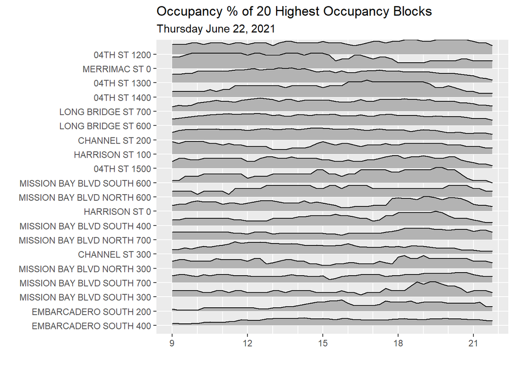

```r
s1 <- occ_panel %>% group_by(street_block) %>% summarise(occ_avg = mean(occ_col)) %>% arrange(-occ_avg) %>% slice(seq(1,nrow(.),20))

s2 <-occ_panel %>% group_by(street_block) %>% summarise(occ_avg = mean(occ_col)) %>% arrange(-occ_avg) %>% slice(1:20)

g<- occ_panel %>% filter(day == 22 & street_block %in% s2$street_block)%>%
  mutate(timeofday = start_interval15 %>% hour() + start_interval15 %>% minute()/60)

ggplot(g)+
  geom_ridgeline(aes(x = timeofday, y = reorder(street_block, occ_col), height = occ_col),
                 scale = 1.2)+
  labs(title = 'Occupancy % of 20 Highest Occupancy Blocks', subtitle = 'Thursday June 22, 2021', y = '', x = '' )+
  scale_x_continuous(breaks =  seq(3,24,3), minor_breaks = seq(1,24,1))+
  theme(panel.grid.minor.x = element_line(size = 0.5))
```